# Laboratorio (hands-on): Reconstrucción básica de una radiografía (Beer–Lambert + haz paralelo)

- Mostrar todo el código
- Ocultar todo el código
- Ver el código fuente

Fuente → Objeto → Detector → (normalización + log) → Radiografía lista para ver

Autor/a

Ph.D. Pablo Eduardo Caicedo Rodríguez

Fecha de publicación

27 de septiembre de 2026

## 1) Introducción

En este laboratorio vas a construir una “radiografía” sintética desde cero, entendiendo la cadena **fuente → objeto → detector**. La idea central es simple: **si un rayo atraviesa más material (o material más atenuante), llegan menos fotones al detector**.

### ¿Qué entra y qué sale?

- **Entra (fuente):** cuántos fotones salen (lo llamaremos `I0`).
- **Entra (objeto):** un mapa 2D `mu[y,x]` que dice qué tan atenuante es cada zona.
- **Sale (detector):** cuántos fotones llegan por rayo (lo llamaremos `I_det`).
- **Sale (radiografía):** una imagen final `rad = -log(I_det/I0)` que es proporcional a “cuánta atenuación acumuló” cada rayo.

### Objetivos de aprendizaje (al finalizar deberías poder)

1. Explicar con palabras simples Beer–Lambert.
2. Construir phantoms 2D con regiones de distintos materiales.
3. Simular proyecciones con **haz paralelo** (sumas en filas).
4. Interpretar `I_det` (más fotones vs menos fotones) y `rad` (más atenuación vs menos).

### Mapa del pipeline (una sola vista)

```
I0 (fuente)  →  tau (suma de μ en el camino)  →  I_det = I0·exp(-tau)  →  rad = -log(I_det/I0)
```

### Glosario rápido (lo mínimo para no perderse)

| Símbolo/variable | Qué es | Cómo se interpreta |
| --- | --- | --- |
| `mu` (μ) | Mapa 2D del objeto | μ grande = material más atenuante |
| `tau` (τ) | Atenuación acumulada por rayo | τ grande = el rayo vio “más bloqueo” |
| `I0` | Intensidad sin objeto | referencia (brillo de la fuente) |
| `I_det` (I) | Intensidad medida con objeto | baja cuando τ sube |
| `rad` | `-log(I_det/I0)` | sube cuando τ sube (radiografía) |

**Nota**

**Regla mental que usarás todo el tiempo** Más `mu` (o más “recorrido” dentro del objeto) → mayor atenuación acumulada `tau` → menor intensidad en el detector `I_det` → mayor valor en la radiografía `rad` (después del log).

## 2) Preparación (imports y parámetros)

Trabajaremos con arreglos 2D `N×N`. En 2D, el detector “natural” es una señal 1D (un valor por fila). Para visualizarlo como imagen, repetiremos esa señal (tiling) y la mostraremos como 2D.

**Código**

```python
import numpy as np
import matplotlib.pyplot as plt

plt.rcParams["figure.dpi"] = 120

N = 256       # tamaño del phantom (rápido en laptop)
dx = 1.0      # tamaño de pixel (unidades arbitrarias)
eps = 1e-12   # evita log(0) si hay valores muy pequeños
```

## 3) Modelo físico: Beer–Lambert (muy claro y sin extras)

### 3.1 La idea (en palabras)

Imagina el objeto como una **cortina** entre la fuente y el detector. - Cortina “ligera” (μ pequeño) → pasan más fotones. - Cortina “pesada” (μ grande) → pasan menos fotones.

`μ(x,y)` es un número que indica qué tan “bloqueador” es el material en ese punto. Un rayo no ve un solo punto: atraviesa una **ruta** y va acumulando bloqueo.

### 3.2 La ecuación

$$I = I_0 \, \exp\left(-\int \mu(x,y)\,dl\right)$$

**Traducción directa (sin misterio):** - `I0`: fotones que llegarían si NO hubiera objeto. - `I`: fotones que llegan DESPUÉS de atravesar el objeto. - `∫ μ dl` (lo llamaremos `tau`): “bloqueo total” acumulado a lo largo del camino del rayo.

### 3.3 Por qué luego usamos log

Si definimos

$$\tau = \int \mu\,dl,$$

entonces

$$\frac{I}{I_0} = e^{-\tau}
\quad\Rightarrow\quad
-\log\left(\frac{I}{I_0}\right)=\tau.$$

O sea: el **log** “deshace” la exponencial y nos devuelve algo proporcional a la atenuación acumulada. Eso es lo que aquí llamamos “radiografía reconstruida”.

**Advertencia**

**Qué NO incluye este laboratorio (a propósito):** no hay scatter, no hay ruido Poisson, no hay endurecimiento de haz, no hay blur del detector. Esto es para aprender el esqueleto del pipeline sin distracciones.

## 4) Construcción de un phantom (mapa 2D de materiales μ)

### 4.1 Qué es un phantom (didáctico)

Un *phantom* es un “objeto inventado” para practicar. Aquí es una imagen 2D de números `mu[y,x]`: cada pixel dice “qué material hay” (qué tanto atenúa). - `mu` pequeño → zona más “transparente” (deja pasar más fotones). - `mu` grande → zona más “opaca” (deja pasar menos fotones).

El fondo representa un material base (`mu_fondo`). Las formas internas tienen otro μ para crear **contraste**.

### 4.2 Cómo “dibujamos” materiales con máscaras

En NumPy podemos construir una **máscara booleana** (True/False). - True = “píntalo con el material del círculo/bloque”. - False = “déjalo como fondo”.

En el siguiente bloque creamos dos phantoms: A) fondo + círculo, B) fondo + bloque + círculo.

**Código**

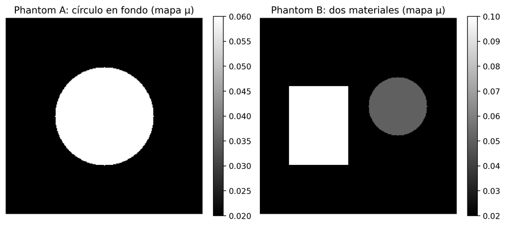

```python
def crear_phantom_circulo(N, mu_fondo=0.02, mu_circulo=0.06, radio_frac=0.25, centro=None):
    """Phantom A: fondo uniforme + un círculo."""
    if centro is None:
        centro = (N//2, N//2)  # (y, x)

    # Grid de coordenadas
    y = np.arange(N)[:, None]
    x = np.arange(N)[None, :]

    cy, cx = centro
    r = radio_frac * N

    # 1) Empieza con fondo
    phantom = np.full((N, N), mu_fondo, dtype=float)

    # 2) Máscara del círculo (True dentro del círculo)
    mascara = (x - cx)**2 + (y - cy)**2 <= r**2

    # 3) "Pinta" el círculo cambiando mu
    phantom[mascara] = mu_circulo
    return phantom

def crear_phantom_dos_materiales(N, mu_fondo=0.02, mu_bloque=0.10, mu_circulo=0.05):
    """Phantom B: fondo + bloque (más atenuante) + círculo (intermedio)."""
    phantom = np.full((N, N), mu_fondo, dtype=float)

    # Bloque rectangular (material más atenuante)
    y1, y2 = int(0.35*N), int(0.75*N)
    x1, x2 = int(0.15*N), int(0.45*N)
    phantom[y1:y2, x1:x2] = mu_bloque

    # Círculo (material intermedio)
    y = np.arange(N)[:, None]
    x = np.arange(N)[None, :]
    cy, cx = int(0.45*N), int(0.70*N)
    r = int(0.15*N)
    mascara = (x - cx)**2 + (y - cy)**2 <= r**2
    phantom[mascara] = mu_circulo

    return phantom

mu_A = crear_phantom_circulo(N)
mu_B = crear_phantom_dos_materiales(N)

fig, ax = plt.subplots(1, 2, figsize=(9, 4))

im0 = ax[0].imshow(mu_A, cmap="gray")
ax[0].set_title("Phantom A: círculo en fondo (mapa μ)")
plt.colorbar(im0, ax=ax[0], fraction=0.046)

im1 = ax[1].imshow(mu_B, cmap="gray")
ax[1].set_title("Phantom B: dos materiales (mapa μ)")
plt.colorbar(im1, ax=ax[1], fraction=0.046)

for a in ax:
    a.set_axis_off()

plt.tight_layout()
plt.show()
```

**Tip**

**Lectura rápida del phantom** En la imagen del phantom NO estás viendo una radiografía. Estás viendo “materiales”: dónde μ es mayor, ese material atenúa más.

### Ejercicio guiado 1 (predicción antes de correr el pipeline)

1. Si aumentas `mu_circulo`, ¿la intensidad `I_det` en esas filas sube o baja? ¿por qué?
2. Si aumentas `mu_bloque`, ¿qué esperas que pase con `I_det` y con `rad`?

Escribe tu predicción en 2–3 líneas. Luego la comprobarás cuando veas `I_det` y `rad`.

## 5) Generador polienergético idealizado (espectro simple)

### 5.1 Qué significa “polienergético” aquí

En rayos X reales, la fuente emite fotones con diferentes energías (un espectro). Aquí lo simplificamos a **3 energías discretas** con **pesos**. Esto es didáctico.

**Importante:** en este laboratorio NO hacemos que μ dependa de energía. Por eso, el “espectro” se reduce a un `I0_total` efectivo, pero nos sirve para entender la idea de “sumar contribuciones”.

### 5.2 Implementación (3 energías + pesos)

**Código**

```
Energías (keV): [30. 60. 90.]
Pesos: [0.5 0.3 0.2]
I0 por energía: [50000. 30000. 20000.]
I0 efectivo: 100000.0
```

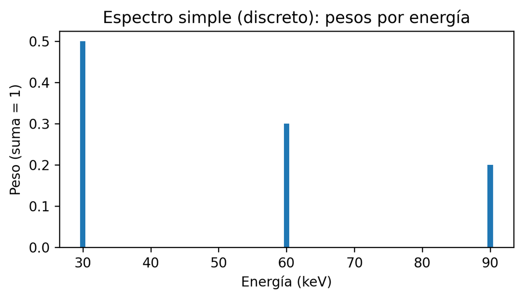

```python
energias_keV = np.array([30, 60, 90], dtype=float)
pesos = np.array([0.50, 0.30, 0.20], dtype=float)
pesos = pesos / pesos.sum()

I0_total = 1e5
I0_por_energia = I0_total * pesos

print("Energías (keV):", energias_keV)
print("Pesos:", pesos)
print("I0 por energía:", I0_por_energia)
print("I0 efectivo:", I0_por_energia.sum())

# Visualización del espectro discreto (solo para ver pesos)
fig, ax = plt.subplots(figsize=(5.5, 3.2))
ax.bar(energias_keV.astype(int), pesos)
ax.set_title("Espectro simple (discreto): pesos por energía")
ax.set_xlabel("Energía (keV)")
ax.set_ylabel("Peso (suma = 1)")
plt.tight_layout()
plt.show()
```

**Pregunta corta (1 línea):** Si μ no cambia con energía, ¿por qué esperarías que `rad = -log(I/I0)` cambie muy poco al cambiar `pesos`?

## 6) Simulación de proyecciones (haz paralelo, integral discreta)

### 6.1 Qué es “proyectar” en este laboratorio

Con **haz paralelo** y en 2D, usaremos rayos horizontales. Para cada fila `y`, el rayo atraviesa todos los pixeles `x` y acumula atenuación:

$$\tau(y) \approx \sum_x \mu(y,x)\,\Delta x$$

`tau(y)` es una señal 1D: un valor por fila (un valor por rayo).

### 6.2 Implementación (sumar en x)

**Código**

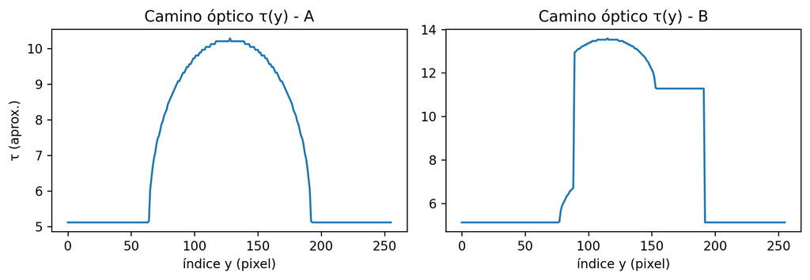

```python
def proyectar_haz_paralelo(mu, dx=1.0):
    """Proyección 2D→1D: tau[y] = sum_x mu[y,x]*dx"""
    tau = np.sum(mu, axis=1) * dx
    return tau

tau_A = proyectar_haz_paralelo(mu_A, dx=dx)
tau_B = proyectar_haz_paralelo(mu_B, dx=dx)

fig, ax = plt.subplots(1, 2, figsize=(9, 3.2))
ax[0].plot(tau_A)
ax[0].set_title("Camino óptico τ(y) - A")
ax[0].set_xlabel("índice y (pixel)")
ax[0].set_ylabel("τ (aprox.)")

ax[1].plot(tau_B)
ax[1].set_title("Camino óptico τ(y) - B")
ax[1].set_xlabel("índice y (pixel)")

plt.tight_layout()
plt.show()
```

### 6.2b Conectar “una fila del phantom” con un valor de τ

Para que no se vuelva abstracto: el rayo de la fila `y0` atraviesa todos los pixeles de esa fila. Entonces `tau[y0]` es literalmente la suma de `mu[y0, :]` (por `dx`). En el siguiente bloque miramos una fila y verificamos la suma.

**Código**

```
Fila y0=128: tau_A[y0]=10.2800  (suma discreta)
Fila y0=128: tau_B[y0]=13.4100  (suma discreta)
```

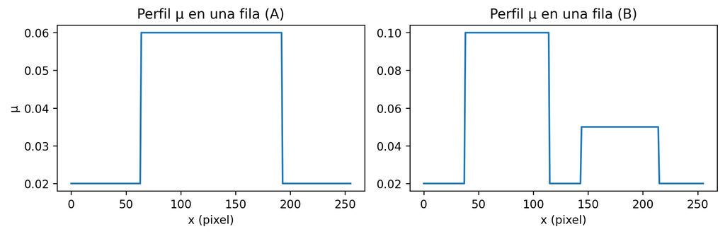

```python
# Escoge una fila (rayo) para inspeccionar
y0 = N // 2

# Perfil de mu en esa fila
perfil_A = mu_A[y0, :]
perfil_B = mu_B[y0, :]

print(f"Fila y0={y0}: tau_A[y0]={tau_A[y0]:.4f}  (suma discreta)")
print(f"Fila y0={y0}: tau_B[y0]={tau_B[y0]:.4f}  (suma discreta)")

fig, ax = plt.subplots(1, 2, figsize=(9, 3))
ax[0].plot(perfil_A)
ax[0].set_title("Perfil μ en una fila (A)")
ax[0].set_xlabel("x (pixel)")
ax[0].set_ylabel("μ")

ax[1].plot(perfil_B)
ax[1].set_title("Perfil μ en una fila (B)")
ax[1].set_xlabel("x (pixel)")

plt.tight_layout()
plt.show()
```

**Nota**

**Interpretación de τ(y)** Si en cierta fila el rayo cruza el círculo o el bloque, τ(y) sube (porque suma μ más grande). Más τ → menos intensidad en el detector (por la exponencial).

### 6.3 Para ver 1D como “imagen” (solo visual)

Esto NO agrega física: solo repite la señal 1D en columnas para verla como imagen.

**Código**

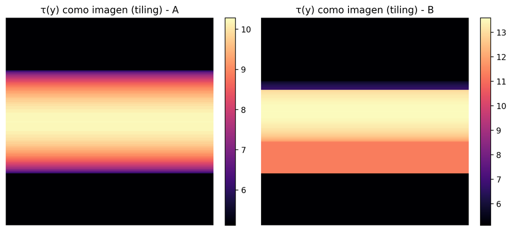

```python
def tile_a_imagen(signal_1d, N):
    """Convierte una señal 1D (N,) a una imagen (N,N) repitiéndola en x."""
    return np.tile(signal_1d[:, None], (1, N))

tau_A_img = tile_a_imagen(tau_A, N)
tau_B_img = tile_a_imagen(tau_B, N)

fig, ax = plt.subplots(1, 2, figsize=(9, 4))
im0 = ax[0].imshow(tau_A_img, cmap="magma")
ax[0].set_title("τ(y) como imagen (tiling) - A")
plt.colorbar(im0, ax=ax[0], fraction=0.046)

im1 = ax[1].imshow(tau_B_img, cmap="magma")
ax[1].set_title("τ(y) como imagen (tiling) - B")
plt.colorbar(im1, ax=ax[1], fraction=0.046)

for a in ax:
    a.set_axis_off()

plt.tight_layout()
plt.show()
```

## 7) Detector ideal (sin blur, sin ruido)

### 7.1 Qué calcula el detector

El detector ideal “cuenta” fotones que llegan por rayo. Para cada energía `k`:

$$I_k(y) = I0_k\,e^{-\tau(y)}$$

y luego sumamos todas las energías:

$$I(y) = \sum_k I_k(y).$$

### 7.2 Implementación

**Código**

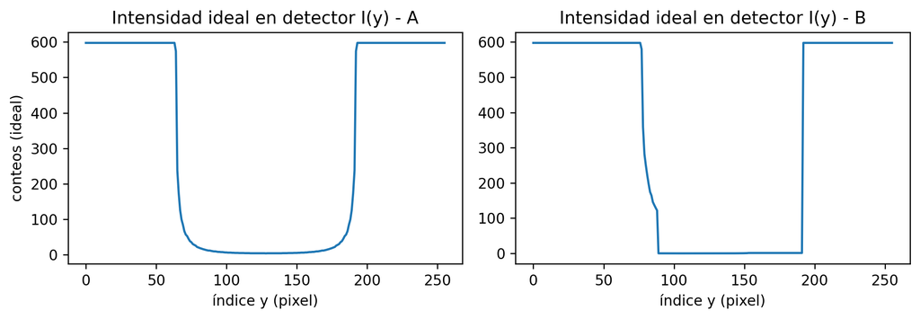

```python
def detector_ideal_polienergetico(tau, I0_por_energia):
    """I(y) = sum_k I0_k * exp(-tau(y))"""
    I = np.zeros_like(tau, dtype=float)
    for I0_k in I0_por_energia:
        I += I0_k * np.exp(-tau)
    return I

I_det_A = detector_ideal_polienergetico(tau_A, I0_por_energia)
I_det_B = detector_ideal_polienergetico(tau_B, I0_por_energia)

fig, ax = plt.subplots(1, 2, figsize=(9, 3.2))
ax[0].plot(I_det_A)
ax[0].set_title("Intensidad ideal en detector I(y) - A")
ax[0].set_xlabel("índice y (pixel)")
ax[0].set_ylabel("conteos (ideal)")

ax[1].plot(I_det_B)
ax[1].set_title("Intensidad ideal en detector I(y) - B")
ax[1].set_xlabel("índice y (pixel)")

plt.tight_layout()
plt.show()
```

### 7.2b Ver la exponencial con tus ojos (τ vs I)

Si Beer–Lambert es correcto, al aumentar `tau` la intensidad debe caer de forma exponencial. En este bloque graficamos `I_det` contra `tau` para ver esa caída.

**Código**

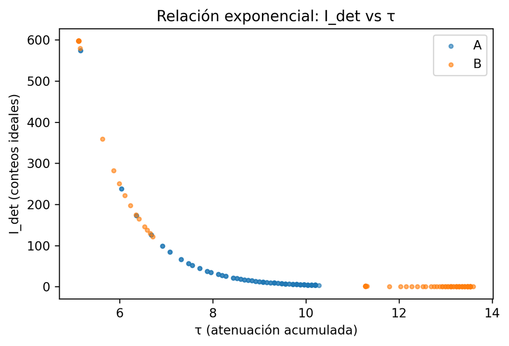

```python
fig, ax = plt.subplots(figsize=(5.8, 4))
ax.scatter(tau_A, I_det_A, s=10, alpha=0.6, label="A")
ax.scatter(tau_B, I_det_B, s=10, alpha=0.6, label="B")
ax.set_title("Relación exponencial: I_det vs τ")
ax.set_xlabel("τ (atenuación acumulada)")
ax.set_ylabel("I_det (conteos ideales)")
ax.legend()
plt.tight_layout()
plt.show()
```

**Tip**

**Cómo “leer” I_det** Picos altos = llegaron muchos fotones (poca atenuación). Valles bajos = llegaron pocos fotones (mucha atenuación).

### Ejercicio guiado 2 (comprobación de tu predicción)

Vuelve al Ejercicio 1. Ahora que ves `I_det`, confirma si tu predicción fue correcta y escribe 2 líneas: - “Subí μ en X → I_det en esa zona **bajó/subió** porque …”.

## 8) Reconstrucción tipo radiografía: normalización + log

### 8.1 Por qué hacemos estos dos pasos

1. **Normalización:** `I_det/I0` elimina el “brillo” de la fuente y deja solo el efecto del objeto.
2. **Log negativo:** como `I/I0 = exp(-tau)`, entonces `-log(I/I0) = tau`.

Esto es clave: la radiografía reconstruida `rad` es proporcional al “camino óptico” `tau`.

### 8.2 Implementación

**Código**

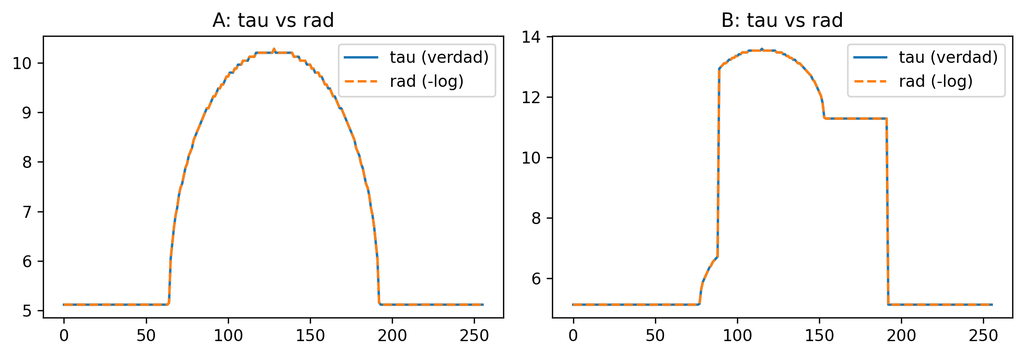

```python
def reconstruir_radiografia(I_det, I0_total, eps=1e-12):
    """rad(y) = -log( I_det(y) / I0_total )"""
    I_norm = (I_det + eps) / (I0_total + eps)
    rad = -np.log(I_norm)
    return rad, I_norm

rad_A, I_norm_A = reconstruir_radiografia(I_det_A, I0_total, eps=eps)
rad_B, I_norm_B = reconstruir_radiografia(I_det_B, I0_total, eps=eps)

# Verificación visual: rad ~ tau
fig, ax = plt.subplots(1, 2, figsize=(9, 3.2))
ax[0].plot(tau_A, label="tau (verdad)")
ax[0].plot(rad_A, "--", label="rad (-log)")
ax[0].set_title("A: tau vs rad")
ax[0].legend()

ax[1].plot(tau_B, label="tau (verdad)")
ax[1].plot(rad_B, "--", label="rad (-log)")
ax[1].set_title("B: tau vs rad")
ax[1].legend()

plt.tight_layout()
plt.show()
```

**Nota**

**Interpretación de rad** Valores altos en `rad` significan: el rayo vio más material (o material más atenuante). Esto suele ser lo que queremos “ver” en una radiografía.

### Ejercicio guiado 3 (invarianza a I0)

Multiplica `I0_total` por 10 (por ejemplo `1e6`) y repite el pipeline. - ¿`I_det` cambia? (sí) - ¿`rad` cambia mucho? (debería cambiar muy poco)

## 9) Visualización: ventaneo (contraste simple)

### 9.1 Por qué ventaneamos

Una radiografía es una matriz de valores, pero el ojo necesita un rango limitado para ver detalles. Ventaneo = escoger un intervalo `[low, high]` y mapearlo a [0,1]. - Ancho pequeño → más contraste, pero se saturan zonas. - Ancho grande → menos contraste, más tonos visibles.

### 9.2 Implementación

**Código**

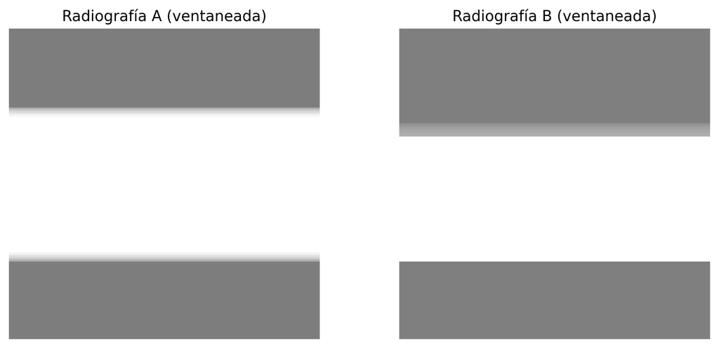

```python
def ventaneo_lineal(img, centro, ancho):
    """
    Ventaneo simple:
    - recorta a [centro - ancho/2, centro + ancho/2]
    - reescala a [0, 1]
    """
    low = centro - ancho/2
    high = centro + ancho/2
    out = np.clip(img, low, high)
    out = (out - low) / (high - low + 1e-12)
    return out

# Convertimos señales 1D a imágenes 2D (tiling) para visualizar
rad_A_img = tile_a_imagen(rad_A, N)
rad_B_img = tile_a_imagen(rad_B, N)

# Ventaneo automático simple con percentiles
centro_A = float(np.median(rad_A))
ancho_A = float(np.percentile(rad_A, 95) - np.percentile(rad_A, 5))
centro_B = float(np.median(rad_B))
ancho_B = float(np.percentile(rad_B, 95) - np.percentile(rad_B, 5))

rad_A_win = ventaneo_lineal(rad_A_img, centro_A, ancho_A)
rad_B_win = ventaneo_lineal(rad_B_img, centro_B, ancho_B)

fig, ax = plt.subplots(1, 2, figsize=(9, 4))
ax[0].imshow(rad_A_win, cmap="gray", vmin=0, vmax=1)
ax[0].set_title("Radiografía A (ventaneada)")
ax[1].imshow(rad_B_win, cmap="gray", vmin=0, vmax=1)
ax[1].set_title("Radiografía B (ventaneada)")

for a in ax:
    a.set_axis_off()

plt.tight_layout()
plt.show()
```

### 9.3 ¿Qué está haciendo el ventaneo? (histograma)

El histograma te muestra cuántos pixeles tienen cierto valor de `rad`. Al ventanear, elegimos un rango `[low, high]` y todo lo demás se recorta. Aquí dibujamos ese rango sobre el histograma para entenderlo.

**Código**

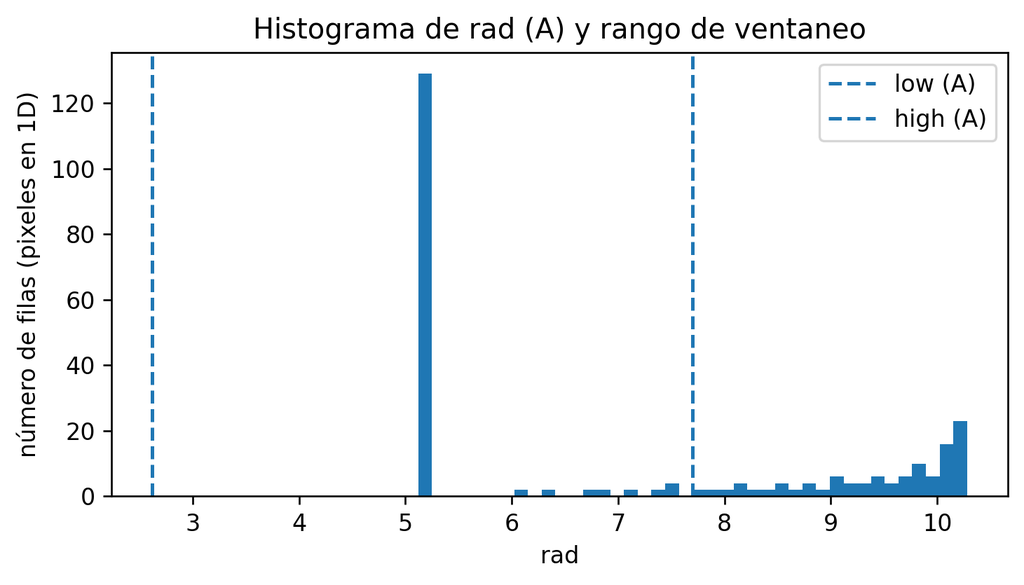

```python
low_A = centro_A - ancho_A/2
high_A = centro_A + ancho_A/2

fig, ax = plt.subplots(figsize=(6.2, 3.6))
ax.hist(rad_A, bins=40)
ax.axvline(low_A, linestyle='--', label='low (A)')
ax.axvline(high_A, linestyle='--', label='high (A)')
ax.set_title("Histograma de rad (A) y rango de ventaneo")
ax.set_xlabel("rad")
ax.set_ylabel("número de filas (pixeles en 1D)")
ax.legend()
plt.tight_layout()
plt.show()
```

### Ejercicio guiado 4 (control de contraste)

Prueba estos cambios y describe en 2–3 líneas qué notas: - Reduce `ancho_A` a la mitad. ¿Qué detalle aparece y qué se satura? - Aumenta `ancho_A` al doble. ¿Qué se ve más “plano” y por qué?

## 10) Comparación final: phantom vs detector vs radiografía

Aquí juntamos todo para leer el pipeline de un vistazo: - `mu` = “qué hay” (materiales). - `I_det` = “qué midió el detector” (conteos). - `rad` = “radiografía” (atenuación acumulada).

**Código**

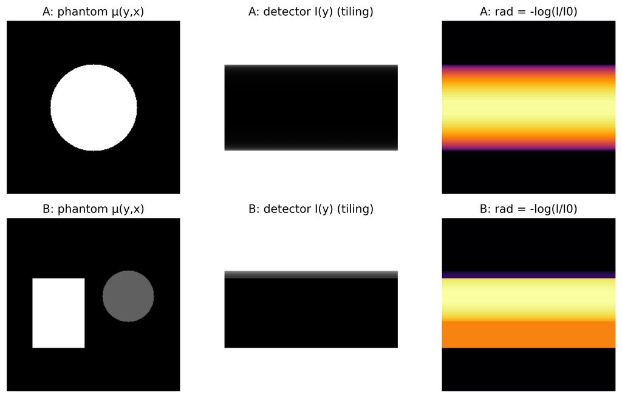

```python
def resumen_pipeline(mu, I0_total, I0_por_energia, dx=1.0, eps=1e-12):
    tau = np.sum(mu, axis=1) * dx
    I_det = detector_ideal_polienergetico(tau, I0_por_energia)
    rad, _ = reconstruir_radiografia(I_det, I0_total, eps=eps)
    return tau, I_det, rad

tauA, IA, radA = resumen_pipeline(mu_A, I0_total, I0_por_energia, dx=dx, eps=eps)
tauB, IB, radB = resumen_pipeline(mu_B, I0_total, I0_por_energia, dx=dx, eps=eps)

fig, ax = plt.subplots(2, 3, figsize=(10, 6))

ax[0,0].imshow(mu_A, cmap="gray"); ax[0,0].set_title("A: phantom μ(y,x)")
ax[1,0].imshow(mu_B, cmap="gray"); ax[1,0].set_title("B: phantom μ(y,x)")

ax[0,1].imshow(tile_a_imagen(IA, N), cmap="gray"); ax[0,1].set_title("A: detector I(y) (tiling)")
ax[1,1].imshow(tile_a_imagen(IB, N), cmap="gray"); ax[1,1].set_title("B: detector I(y) (tiling)")

ax[0,2].imshow(tile_a_imagen(radA, N), cmap="inferno"); ax[0,2].set_title("A: rad = -log(I/I0)")
ax[1,2].imshow(tile_a_imagen(radB, N), cmap="inferno"); ax[1,2].set_title("B: rad = -log(I/I0)")

for a in ax.ravel():
    a.set_axis_off()

plt.tight_layout()
plt.show()
```

## 11) Mini-proyecto final (entregable)

Tu objetivo: crear tu propio phantom (al menos 2 materiales) y generar su radiografía. Debes incluir 3 figuras: (1) phantom, (2) intensidad del detector, (3) radiografía final ventaneada. Luego escribe un párrafo corto interpretando (5–8 líneas) qué zonas atenúan más y cómo se ven.

**Código**

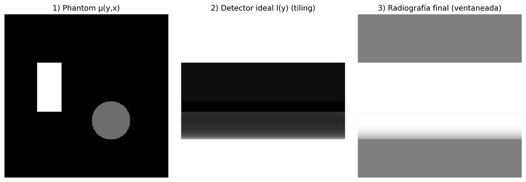

```python
def crear_phantom_estudiante(N):
    mu_fondo = 0.02
    phantom = np.full((N, N), mu_fondo, dtype=float)

    # TODO: forma 1 (más atenuante): bloque
    phantom[int(0.30*N):int(0.60*N), int(0.20*N):int(0.35*N)] = 0.09

    # TODO: forma 2 (intermedia): círculo
    y = np.arange(N)[:, None]
    x = np.arange(N)[None, :]
    cy, cx = int(0.65*N), int(0.65*N)
    r = int(0.12*N)
    phantom[(x - cx)**2 + (y - cy)**2 <= r**2] = 0.05

    return phantom

mu_est = crear_phantom_estudiante(N)

# Proyección + detector + radiografía
tau_est = np.sum(mu_est, axis=1) * dx
I_det_est = detector_ideal_polienergetico(tau_est, I0_por_energia)
rad_est, _ = reconstruir_radiografia(I_det_est, I0_total, eps=eps)

# A imagen para visualizar
I_det_est_img = tile_a_imagen(I_det_est, N)
rad_est_img = tile_a_imagen(rad_est, N)

# Ventaneo automático simple
centro_est = float(np.median(rad_est))
ancho_est = float(np.percentile(rad_est, 95) - np.percentile(rad_est, 5))
rad_est_win = ventaneo_lineal(rad_est_img, centro_est, ancho_est)

# 3 figuras requeridas
fig, ax = plt.subplots(1, 3, figsize=(12, 4))

ax[0].imshow(mu_est, cmap="gray")
ax[0].set_title("1) Phantom μ(y,x)")
ax[0].set_axis_off()

ax[1].imshow(I_det_est_img, cmap="gray")
ax[1].set_title("2) Detector ideal I(y) (tiling)")
ax[1].set_axis_off()

ax[2].imshow(rad_est_win, cmap="gray", vmin=0, vmax=1)
ax[2].set_title("3) Radiografía final (ventaneada)")
ax[2].set_axis_off()

plt.tight_layout()
plt.show()
```

**Interpretación (5–8 líneas, escribe aquí en tu entrega):** - ¿Dónde está el material más atenuante? ¿Cómo se ve en `I_det` y en `rad`? - ¿Qué zonas dejan pasar más fotones? - ¿El ventaneo te ayudó a ver bordes o materiales? ¿Por qué?

## 12) Entregables (checklist de evaluación)

- El código corre sin errores al renderizar el HTML.
- Se ven (o se exportan) 3 figuras del mini-proyecto:
  - Phantom (`mu_est`)
  - Intensidad en detector (`I_det_est`)
  - Radiografía final (`rad_est` con ventaneo)
- Interpretación corta (5–8 líneas) en lenguaje claro.
- (Opcional) Cambia el “espectro simple” (`pesos`) y comenta qué cambia.
  - Pista: con este modelo (sin μ dependiente de energía), `rad` debería cambiar muy poco.

## Apéndice (opcional): exportar figuras a PNG

Si necesitas entregar archivos, usa `savefig`. No es obligatorio si todo queda visible en el HTML.

**Código**

```python
# Ejemplo (descomenta si quieres guardar):
# plt.figure()
# plt.imshow(mu_est, cmap="gray")
# plt.axis("off")
# plt.title("Phantom del estudiante")
# plt.savefig("phantom_est.png", dpi=150, bbox_inches="tight")
# plt.close()
```